# Spatial Data Analysis (450:320)

Class 5

The code behind the title page map:

```r
# Get the annual mean temperature
temp <- rast(system.file("extdata/bioclim.tif", package = "sdadata"), lyr = 1)

# Reproject
temp <- temp %>% project("EPSG:3035")

rnaturalearth::ne_countries(returnclass = "sf", scale = 50) %>%
    st_transform(3035) %>%
    ggplot() +
    geom_sf(fill = "lightblue") +
    geom_spatraster(data = temp) +
    scale_fill_viridis_c("Degree", na.value = NA) +
    theme_classic() +
    theme(plot.background  = element_rect(fill = "transparent", color = NA),
    panel.background = element_rect(fill = "transparent", color = NA))
```

[output not shown]

## So far…

- We should know:
  - All essential housekeeping tasks (Git, GitHub, etc)
  - A lot more about `data.frame`, `vector` and `list`
  - Basic concepts related to functions in R

## Today

- More on data structure
- More on functions
- Environments and Scoping

## Vector calculation

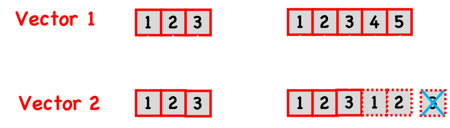

## Practice 1

- Create a numeric vector `x1` of length **8** with values between 1-10.
- Create another vector `x2` of length **3** with values between 1-10.
- Run `x1 + x2`, `x1 * c(x2, 1)`, observe what is going on.
- Run `c(x1, x2)`, `rbind(x1, x2)`, and `cbind(x1, c(x2, 1))`.

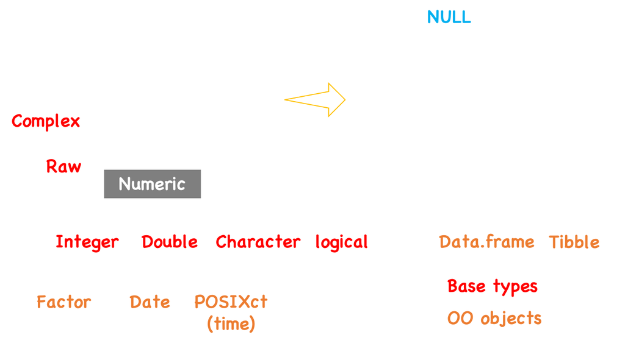

## One example

```r
x <- data.frame(name = "Lei", role = "instructor")
typeof(x)
```

```
[1] "list"
```

```r
class(x)
```

```
[1] "data.frame"
```

```r
class(x) <- c("Lei", class(x)) # Very flexible, but sloppy way
# Note: There is formal way
class(x)
```

```
[1] "Lei"        "data.frame"
```

```r
is(x, "data.frame")
```

```
[1] TRUE
```

```r
is(x, "Lei")
```

```
[1] TRUE
```

- **Task for you**: create your own version of `x` about yourself. The role could be anything: e.g., student, football player, cat lover, meteorologist, geographer, etc. Then update the class of `x` to include your name, just like what I did.
- Print your `x` out.

## Factor

- Create a factor `x_f` and `f`:

```r
x_f <- factor(c("John", "Chris", "Rachel"))
f <- factor(c(1:4, 10))
x_f
f
```

## Factor

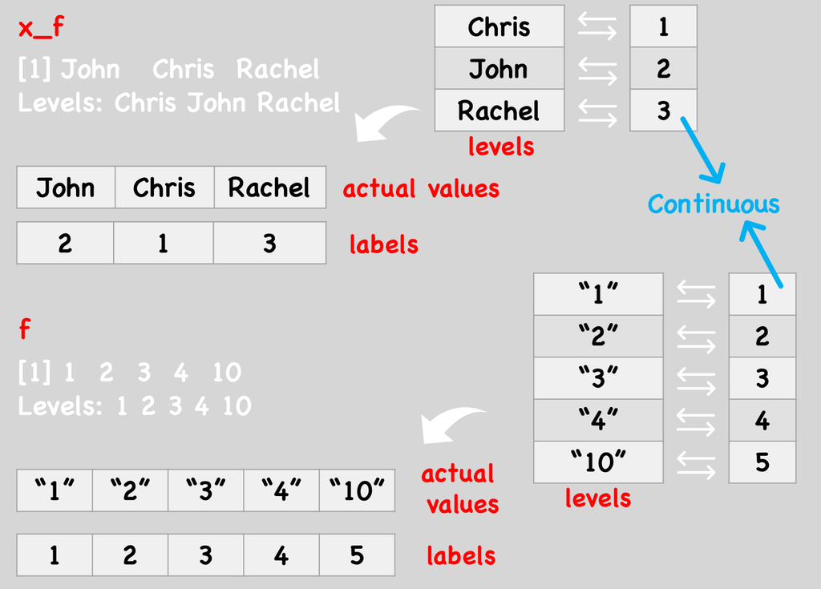

## Practice 2

- Have a guess what will be printed out?

```r
levels(x_f)

labels(x_f)

as.integer(x_f)

as.character(x_f)
```

## Practice 2

- How about `f`?

```r
levels(f)

labels(f)

as.integer(f)

as.character(f)
```

- Challenge: what if I want to convert `f` to integer, but keep the original values?

## Specify the levels

- Customize the order of the levels.

```r
x_f2 <- factor(c("John", "Chris", "Rachel"), levels = c("John", "Chris", "Rachel"))
x_f2
x_f
```

## Something more crazy

- Remap the values (usually not necessary).

```r
x_f3 <- factor(c("John", "Chris", "Rachel"),
               levels = c("John", "Chris", "Rachel"), # map from
               labels = c("Male", "Male", "Female")) # map to
x_f3
levels(x_f3)
labels(x_f3)
```

## Functions

Invoking a function is straightforward, just type the function name and give it the necessary parameters.

```r
sum(1, 3)

# Assign the result to an object
a <- sum(c(1:10))

is.vector(a)

# open the help document using ?+function_name
?sum
```

**What is generic function?**

## Generic function

Can be extended

```r
plot(x = 1:10, y = 2:11)

# Check if x is still yourself
is(x, "Lei")
plot(x)

plot.Lei <- function(obj){
    print(obj$name)
}
plot(x)

methods("plot")
```

- **your task:** create a function `plot` for yourself class. Let the function do something that you want.

## Function components

```r
function_name <- function(arg1,
                          arg2 = 1:10,
                          arg3 = ifelse(arg2 == 2, TRUE, FALSE)){
  body
}
```

Three essential components of a function:

- `formals()`, which is a list of arguments. Could be NULL.
- `body()`, the code in the function. R function will return the last thing generated by the function body automatically. If you want to return something else, use `return(x)`.
- `environment()`, where the function finds the values. It might change based on where the function is defined.

**Without name**, the function is called **anonymous** function (quite useful in many cases).

## Practice 3

- Define a function to convert Fahrenheit to Celsius.

$$Celsius = (Fahrenheit - 32) / 1.8$$

- Exam temperatures in Fahrenheit `c(70, 34, 25, 10, 89, 92, 15)`, when the temperature in Celsius is lower than -10, give a warning “Stay inside.” and print out this temperature in Celsius.

```r
# Define the function
c_to_f <- function(fah = 0){
  # Add your code
}

# Initialize the temperature vector
fahs <- c(70, 34, 25, 10, 89, 92, 15)

# Loop over the temperature to check
for (fah in fahs){
    # Call your function
    cel <- c_to_f(fah)
    if (cel < -10){
        # Add your code
    }
}
```

## Practice 3

```r
# Define the function
c_to_f <- function(fah = 0){
  # This is a function to convert Fahrenheit to Celsius.
  # The argument is fah with a default value 0.
  (fah - 32) / 1.8
}

# Initialize the temperature vector
fahs <- c(70, 34, 25, 10, 89, 92, 15)

# Loop over the temperature to check
for (fah in fahs){
  cel <- c_to_f(fah)
  if (cel < -10){
    print('Stay inside.')
    print(cel)
  }
}
```

```
[1] "Stay inside."
[1] -12.22222
```

## Lexical scoping

Let’s guess some results:

```r
# Name masking
x <- 10
f1 <- function() {
  x <- 1
  x <- x + 1
  print(x)
}
f1()
x
```

```r
# Search level up
x <- 10
f1 <- function() {
  y <- 12
  f2 <- function(){
    z <- 14
    print(x + y + z)
  }
  f2()
}
f1()

# What about this?
x <- 10
f1 <- function(x) {
  print(x)
}
f1()
```

## Environment and namespace

[figure not shown]

## For example

```r
my_number_checker <- function(x) {
    if(x < 5) {
        print("Too low!")
    } else if(x > 5 & x < 10) {
        print("Just right!!! :)")
    } else {
        print("Too high!")
    }
}

library(ls320)

# Remove the function from R_GlobalEnv
rm(my_number_checker)
# Unload ls320
detach("package:ls320", unload = TRUE)

library(ls320)
library(DG320)
```

## Homework

- **Read** Section 1-3 in Unit1-Module3.
- Sync your class notes of this week to Github
  - I will check them for **participation**
  - I might give **bonus point** for impressive ones
- Make sure you are okay with GitHub (**!!**)